# Peer speech project

Out of the lab corpora: Linaza, Vila, SerraSole, Marrero, Aguirre, OreaPine, Nieva, Ornat, Romero, Geneva, Pauline, Champaud, York, Leveille, Clark, Brown, Kuczaj, Providence, Sachs, Hall, Snow, Valian, Post, Gleason, Suppes, Braunwald, Bloom70, Caroline, Wagner, Rigol, Miller, Leo, Gaeltacht, ZhouDinner, TCCM, Beijing, LeeWongLeung, Utrecht, Wijnen, Stellenbosch, Thomas, Forrester, Wells, MPI-EVA-Manchester, Lara, Belfast, SCECL, Kovacevic, Tanja, Protassova, Antelmi, Calambrone, Klammler, Roma, Florianopolis, Santos, Jordina, Julia, MireiaEvaPascual, Avram, Ishii, Miyata, MiiPro, Hamasaki, Plunkett, Kari, Ringstad, Jiwon, Ryu, Jakarta, Demuth, Soto, Bodor, Reger, Vija, Beek, Korgesaar, Zupping, Argus, Kohler, Narasimhan, Doukas, Levy, BatEl, Ravid, BSF, Samadi, Family

Number of out of the lab corpora: 88

Role tags in all CHILDES : Target_Child, Father, Brother, Mother, Investigator, Adult, Unidentified, Observer, Sister, Child, Girl, Aunt, Playmate, Grandmother, Uncle, Family_Friend, Grandfather, Visitor, Cousin, Boy, Camera_Operator, Babysitter, Teenager, Toy, Environment, Non_Human, Student, Teacher, Sibling, Housekeeper, Media, Doctor, Group, Caretaker, Speaker, Nurse, Target_Adult

```r
#finds corpora with peer speech
namePeerSpeech=list()
dataPeer=list()

#3 CHECK: all cousins, boys etc Nnot adults?
childSpeakers=c("Sister", "Brother", "Playmate", "Teenager", "Cousin", "Child", "Girl", "Sibling", "Boy")

cSelectPeer=subset(cSelect, (cSelect$role %in% childSpeakers))
peerCorpusName=unique(cSelectPeer$corpus_name)
```

Out of lab CHILDES corpora with child speech (tags= Sister, Brother, Playmate, Teenager, Cousin, Child): Linaza, Vila, SerraSole, Marrero, Aguirre, Romero, Geneva, Pauline, Champaud, York, Clark, Brown, Kuczaj, Providence, Sachs, Hall, Valian, Post, Gleason, Suppes, Braunwald, Bloom70, Caroline, Wagner, Rigol, Miller, Leo, Gaeltacht, ZhouDinner, TCCM, Beijing, LeeWongLeung, Stellenbosch, Forrester, Wells, MPI-EVA-Manchester, Lara, Belfast, SCECL, Kovacevic, Calambrone, Santos, Jordina, MireiaEvaPascual, Ishii, Miyata, MiiPro, Hamasaki, Plunkett, Kari, Ryu, Jakarta, Demuth, Soto, Bodor, Reger, Vija, Korgesaar, Zupping, Argus, Kohler, Levy, BatEl, Ravid, BSF, Samadi, Family

Number of CHILDES corpora with peer speech: 67

```r
# counts number of utterances per speaker for the selected out-of-lab corpora
#This chunk takes time to compute!


#for (name in peerCorpusName[1:2]) {   #choosing only first 2 corpora to have it compile faster!

i=1
total<-data.frame(speaker_role=unique(cSelect$role))

for (name in peerCorpusName) {   #choosing only first 2 corpora to have it compile faster!
  i=i+1
  utts<-get_utterances(corpus=name)
  ex=data.frame()
  ex<- utts %>% group_by(speaker_role) %>% tally()
  ex$n <- as.numeric(as.character(ex$n)) / sum(ex$n)
  total<- left_join(total, ex )
  colnames(total)[i]<-name
}
total[is.na(total)] <- 0
total$Rmean <-rowMeans(total[2:3])
total$Rsd <- apply(total[2:3], 1, sd)
total$Rmean<- round(total$Rmean, 2)
total$Rsd<- round(total$Rsd, 2)
total

total_specific<- total  %>% select(speaker_role, Rmean, Rsd)

total_specific<- subset(total_specific, !(total_specific$Rmean==0))

library(ggplot2)
p<-ggplot(total_specific, aes(x=speaker_role, y=Rmean, fill=speaker_role)) + geom_bar(stat="identity") + labs(title="Mean input ratio across CHILDES", x="Speaker role", y = "Mean input ratio")
p
```

```r
# counts number of utterances per speaker for the selected out-of-lab corpora with wireless recordings

tablew=data.frame()

#4 CHECK if only these
wirelessCorpusName<-c("Wells", "Demuth", "Hall")

i=1
for (name in wirelessCorpusName) {
  cw<-get_utterances(corpus=name)
  tabletmp<-cw %>% group_by(speaker_role) %>% summarise(no_rows = length(speaker_role))
  tablew<-rbind(tablew, tabletmp)
  i=i+1}
tablew

nuttsWirelessSummary<-tablew %>% group_by(speaker_role) %>% summarise(no_rows = sum(no_rows))
nuttsWirelessSummary
```

```r
lang<-"Sesotho"

#reads demuth corpus and counts utterances per speaker
demuth<-read.csv(file="sesotho_emilie_CDI.csv", header=TRUE) # memory processing problems, can't load googlesheets

#mark corpus by keychild cs: I checked twice i someone wants to double check awesome
demuth$keychild <- NA
demuth$keychild[demuth$session_id_fk.x %in% c(2414:2458)] <- "Hlobohang"
demuth$keychild[demuth$session_id_fk.x %in% c(2459:2503)] <- "Litlhare"
demuth$keychild[demuth$session_id_fk.x %in% c(2504:2542)] <- "Tsebo"


#number of utterances per speaker

demuth$speaker[demuth$role_raw == "Mother"] <- "mother"
demuth$speaker[demuth$role_raw == "Investigator"] <- "investigator"
demuth$speaker[grep("Sister|Brother|Sibling", demuth$role_raw)]  <- "sibling"
demuth$speaker[grep("Child|Playmate|child|Teenager|Cousin", demuth$role_raw)]  <- "peer"
demuth$speaker[grep("Adult|Uncle|Grandmother|Family_Friend|Visitor|Aunt|Father", demuth$role_raw)]  <- "adult"
demuth$speaker[grep("Target", demuth$role_raw)] <- "Target_Child"


#save changes
write.table(demuth, file=paste0("demuth_input.txt"), row.names=F, col.names=T,  quote=F)

#Sum the number of utterances per speaker category and keychild
aggregate(demuth$utterance_id,by=list( demuth$speaker, demuth$keychild),length )->sum_demuth
colnames(sum_demuth) <- c("speaker", "keychild", "nb_utt")

#lenght demuth by child
trybis<- demuth %>% group_by(keychild) %>% summarise(no_rows = length(keychild)) # 11866

#sesotho_speakers<- demuth %>% group_by(role_raw) %>% summarise(no_rows = length(role_raw))
#number  of total input utterances
#total_demuth_input<-sum(sesotho_speakers_input$no_rows)
```

```r
#ADRESSEE ANNOTATIONS PART

#annotated utterances by Emilie

demuth_annotated<-demuth[1:36782,]   #this is 53% annotated is this correct ???

#Sum the number of utterances per speaker category and keychild
aggregate(demuth_annotated$utterance_id,by=list( demuth_annotated$speaker, demuth_annotated$keychild),length )->sum_demuth_annotated
colnames(sum_demuth_annotated) <- c("speaker", "keychild", "nb_utt")


#Sum the number of utterances per speaker category and keychild and ADDRESSEE
aggregate(demuth_annotated$utterance_id,by=list(demuth_annotated$childdirected,  demuth_annotated$speaker, demuth_annotated$keychild),length )->sum_demuth_addressee
colnames(sum_demuth_addressee) <- c("addresse", "speaker", "keychild", "nb_utt")

# Utterances addressed to the target child  aka CDS
demuth_child_directed<-subset(demuth_annotated, (demuth_annotated$childdirected==1))

aggregate(demuth_child_directed$utterance_id,by=list(demuth_child_directed$speaker, demuth_child_directed$keychild),length )->sum_demuth_CDS
colnames(sum_demuth_CDS) <- c( "speaker", "keychild", "nb_utt")

#Remove all target child aka the one recorded utterances
demuth_annotated_input<-subset(demuth_annotated, !(demuth_annotated$role_raw=="Target_Child"))

#classify into categories the different speakers
demuth_annotated_input$childdirected<-as.factor(demuth_annotated_input$childdirected)
#total utterances
total_demuth_annotated_input<-length(demuth_annotated_input$utterance_id) # 21042

##CREATE TABLE of different speakers in the corpus
demuth_annotated_table<- demuth_annotated_input %>% group_by(childdirected) %>% summarise(no_rows = length(childdirected))#there is a warning message about:  Factor `childdirected` contains implicit NA, consider using `forcats::fct_explicit_na`
#treat the table as a data.frame
demuth_annotated_table<-as.data.frame(demuth_annotated_table)
# re order by descending number
demuth_annotated_table<- demuth_annotated_table %>%   arrange(desc(no_rows))
demuth_annotated_table
```

```
##     childdirected no_rows
## 1               1   18013
## 2               ?     614
## 3               A      99
## 4           16434      60
## 5            <NA>      40
## 6           16779      39
## 7             MIX      38
## 8           16502      37
## 9           16455      34
## 10          16711      32
## 11          16631      31
## 12          16713      31
## 13              O      31
## 14          16773      30
```

[output cut: 270 more lines]

```r
# Utterances addressed to the target child  aka CDS
demuth_child_directed<-subset(demuth_annotated_input, (demuth_annotated_input$childdirected=="1"))
demuth_cd_directed_utts<- as.data.frame(demuth_child_directed %>%select(utterance))
write.table(demuth_cd_directed_utts, file=paste0(lang, "Demuthchilddirected.txt"), row.names=F, col.names=T,  quote=F)  ##!!!  i slighlty change this so be careful if you use it in CLAN or elsewhere from childdirected.txt to Demuthchilddirected.txt

#percentage of child directed speech vs total annotated
length(demuth_child_directed$utterance)/total_demuth_annotated_input *100 #85.60498
```

```
## [1] 85.60498
```

```r
#matches addressee with speaker roles (especially for non-child directed)
speaker_info_demuth<- as.data.frame(unique(demuth %>%select(speaker_id, role_raw)))
colnames(speaker_info_demuth)[colnames(speaker_info_demuth)=="role_raw"] <- "role_adressee"
annotated_speaker_info_demuth<-merge(x=demuth_annotated_input, y=speaker_info_demuth, by.x="childdirected", by.y="speaker_id", all.x=TRUE, sort=TRUE)

# Utterances addressed to adults aka ADS (basically anything that is not a known child right?)
demuth_adult_directed<-subset(annotated_speaker_info_demuth, !(annotated_speaker_info_demuth$role_adressee=="Playmate"| annotated_speaker_info_demuth$role_adressee=="Cousin"|annotated_speaker_info_demuth$role_adressee=="?"| annotated_speaker_info_demuth$childdirected=="SELF"| annotated_speaker_info_demuth$role_adressee=="SELF"| annotated_speaker_info_demuth$role_adressee=="Brother"| annotated_speaker_info_demuth$childdirected=="NA"| annotated_speaker_info_demuth$role_adressee=="Teenager"|annotated_speaker_info_demuth$role_adressee=="Sister"|annotated_speaker_info_demuth$childdirected=="1"|annotated_speaker_info_demuth$childdirected=="0"|annotated_speaker_info_demuth$childdirected=="O"))

aggregate(demuth_adult_directed$utterance_id,by=list(demuth_adult_directed$speaker, demuth_adult_directed$keychild),length )->sum_demuth_ADS
colnames(sum_demuth_ADS) <- c( "speaker", "keychild", "nb_utt")

#subset all utterances marked as ADS
demuth_ad_directed_utts<- as.data.frame(demuth_adult_directed %>%select(utterance))
#export all ADS utterance into a text file
write.table(demuth_ad_directed_utts, file=paste0("Sesothoadultdirected"), row.names=F, col.names=T,  quote=F)

#percentage of adult directed speech vs total annotated
length(demuth_adult_directed$utterance)/total_demuth_annotated_input *100 #4.148845
```

```
## [1] 4.148845
```

```r
#Utterances marked as NO directed speech
demuth_na_directed<-subset(demuth_annotated_input, (demuth_annotated_input$childdirected=="NA" |demuth_annotated_input$childdirected=="?"  ))
demuth_nodirected_utts<- as.data.frame(demuth_na_directed %>%select(utterance))
#write.table(demuth_nodirected_utts, file=paste0( lang, "Demuth_nodirected"), row.names=F, col.names=T,  quote=F) !!! ALSO NAME CHANGED !!!

#percentage of child directed speech vs total annotated
length(demuth_na_directed$utterance)/total_demuth_annotated_input *100 #2.917974
```

```
## [1] 2.917974
```

```r
#Utterances type analysis

#Utterances marked as CDS
demuth_sentence_type_child_annotated<- demuth_child_directed %>% group_by(sentence_type) %>% summarise(no_rows = length(sentence_type))
#Utterances marked as questions
directed_questions<-subset(demuth_sentence_type_child_annotated, (demuth_sentence_type_child_annotated$sentence_type=="question"))
#percentage marked as questions in CDS annotated corpus
directed_questions$no_rows/sum(demuth_sentence_type_child_annotated$no_rows) *100 #40.12102
```

```
## [1] 40.12102
```

```r
#Sentences marked as ADS
demuth_sentence_type_adult_annotated<- demuth_adult_directed %>% group_by(sentence_type) %>% summarise(no_rows = length(sentence_type))
#Utterances marked as questions
adultdirected_questions<-subset(demuth_sentence_type_adult_annotated, (demuth_sentence_type_adult_annotated$sentence_type=="question"))
#percentage marked as questions in ADS annotated corpus
adultdirected_questions$no_rows/sum(demuth_sentence_type_adult_annotated$no_rows)*100 #20.38946
```

```
## [1] 20.38946
```

```r
library(reshape2)

#add label of type of input
sum_demuth_ADS$input <- "ADS"
sum_demuth_CDS$input <- "CDS"

#remove for CDS the target child utterances in which he is talking to himself
sum_demuth_CDS<-subset(sum_demuth_CDS, !(sum_demuth_CDS$speaker=="Target_Child"))
sum_demuth_ADS<-subset(sum_demuth_ADS, !(sum_demuth_ADS$speaker=="Target_Child"))


#make sure that all children have the 4 categories ,if not mark as 0
#CDS
table(sum_demuth_CDS$keychild,sum_demuth_CDS$speaker) #check
```

```
##
##             adult investigator mother peer sibling
##   Hlobohang     1            1      1    1       0
##   Litlhare      1            1      1    1       1
```

```r
#create the lines (this should be done via a loop sorry!)
peer_Hlo <- data.frame("sibling","Hlobohang", "0", "CDS")
#names the lines
names(peer_Hlo)<-c("speaker","keychild", "nb_utt","input")
neww <- rbind(sum_demuth_CDS, peer_Hlo)
#added to the main data.frame
sum_demuth_CDS <- rbind(sum_demuth_CDS, peer_Hlo)


#ADS
table(sum_demuth_ADS$keychild,sum_demuth_ADS$speaker) #check
```

```
##
##             adult investigator mother peer sibling
##   Hlobohang     1            1      1    1       0
##   Litlhare      1            1      1    1       1
```

```r
#create the lines (this should be done via a loop sorry!)
peer_Hlo <- data.frame("sibling","Hlobohang", "0", "ADS")
#names the lines
names(peer_Hlo)<-c("speaker","keychild", "nb_utt","input")
neww <- rbind(sum_demuth_ADS, peer_Hlo)
#added to the main data.frame
sum_demuth_ADS <- rbind(sum_demuth_ADS, peer_Hlo)

demuth_fig <-rbind(sum_demuth_ADS,sum_demuth_CDS)

# trywells <- melt(sum_wells_ADS[,c("child","tot.adults", "tot.children")],id.vars = 1)
# colnames(dfm) <- c("child", "input", "value")
# dft <- melt(bigsum_low[,c("child","cds.adults", "cds.children")],id.vars = 1)
# colnames(dft) <- c("child", "input.cds", "value.cds")
# cbind(dfm,dft) -> try
# try[4] <- NULL
# merge(x=bigsum_low,y = try[ , c("child",  "input", "value", "input.cds", "value.cds"),], all.x=T,all.y=F)->try2
```

```r
#load Wells data

lang<-"English"
wells<-read.csv(file="/Users/lscpuser/Documents/peerproject/peerproject/wells.csv", header=T) #11,866
wells[6]<-NULL

#mark corpus by keychild cs: I checked twice i someone wants to double check awesome
wells$keychild <- NA
wells$keychild [1:2278] <- "benjamin"
wells$keychild [2279:3400] <- "samantha"
wells$keychild [3401:3962] <- "debbie"
wells$keychild [3963:4776] <- "sheila"
wells$keychild [4777:5601] <- "stella"
wells$keychild [5602:7224] <- "abigail"
wells$keychild [7225:9038] <- "geoffrey"
wells$keychild [9039:10909] <- "harriet"
wells$keychild [10910:11866] <- "laura"

#add gender
wells$gender [wells$keychild == "benjamin"] <- "M"
wells$gender [wells$keychild == "samantha"] <- "F"
wells$gender [wells$keychild == "debbie"] <- "F"
wells$gender [wells$keychild == "samantha"] <- "F"
wells$gender [wells$keychild == "sheila"] <- "F"
wells$gender [wells$keychild == "stella"] <- "F"
wells$gender [wells$keychild == "abigail"] <- "F"
wells$gender [wells$keychild == "geoffrey"] <- "M"
wells$gender [wells$keychild == "harriet"] <- "F" #assuming girl
wells$gender [wells$keychild == "laura"] <- "F"


#remove target child utts  aka 4,830 entries
#wells_input<- wells[!grepl("Target", wells$ROLE),]
wells$speaker[wells$ROLE == "Mother"] <- "mother"
wells$speaker[grep("Sister|Brother|Sibling", wells$ROLE)]  <- "sibling"
wells$speaker[grep("Child|Playmate|child", wells$ROLE)]  <- "peer"
wells$speaker[grep("Adult|Uncle|Grandmother|Family_Friend|Visitor|Aunt|Father", wells$ROLE)]  <- "adult"
wells$speaker[grep("Target", wells$ROLE)] <- "Target_Child"


#name and save data
colnames(wells)<-c("NAME"   ,   "ROLE"   ,   "UTTERANCE", "COMMENT"  , "DIRECTED"    ,  "keychild" , "gender"   , "speaker")

wells[] <- lapply(wells, gsub, pattern='\t', replacement='')

write.table(wells, file=paste0("wells_input.csv"), row.names=F, col.names=T,  quote=F, sep='\t')

#Sum the number of utterances per speaker category and keychild
aggregate(wells$UTTERANCE,by=list( wells$speaker, wells$keychild),length )->sum_wells
colnames(sum_wells) <- c("speaker", "keychild", "nb_utt")


try<- wells %>% group_by(keychild) %>% summarise(no_rows = length(keychild)) # 11866

#
```

```r
#NOT WORKING FOR SOME REASON:
read.table("wells_input.csv",header=F, sep='\t', fill = TRUE)->wells_input
colnames(wells_input)<-c("NAME"   ,   "ROLE"   ,   "UTTERANCE", "COMMENT"  , "DIRECTED"    ,  "keychild" , "gender"   , "speaker")

#ADRESSEE ANNOTATIONS PART  #6785 ~ 57.2%
wells_annotated_input<-subset(wells, !(wells$DIRECTED=="")) #select utterances annotated by Naomi Alex up to now , for now 3098 rows PLEASE UPDATE as we go !!

#Sum the number of utterances per speaker category and keychild
aggregate(wells_annotated_input$UTTERANCE,by=list( wells_annotated_input$speaker, wells_annotated_input$keychild),length )->sum_wells_annotated
colnames(sum_wells_annotated) <- c("speaker", "keychild", "nb_utt")


#Sum the number of utterances per speaker category and keychild and ADDRESSEE
aggregate(wells_annotated_input$UTTERANCE,by=list(wells_annotated_input$DIRECTED,  wells_annotated_input$speaker, wells_annotated_input$keychild),length )->sum_wells_addressee
colnames(sum_wells_addressee) <- c("addresse", "speaker", "keychild", "nb_utt")

# Utterances addressed to the target child  aka CDS 2181*100/6785 = 32%
wells_child_directed<-subset(wells_annotated_input, (wells_annotated_input$DIRECTED=="CHI"))

aggregate(wells_child_directed$UTTERANCE,by=list(wells_child_directed$speaker, wells_child_directed$keychild),length )->sum_wells_CDS
colnames(sum_wells_CDS) <- c( "speaker", "keychild", "nb_utt")
write.table(sum_wells_CDS, file=paste0("sum_wells_CDS.txt"), row.names=F, col.names=T,  quote=F)


#subset all utterances marked as CDS
wells_child_directed<-subset(wells_child_directed, !(wells_child_directed$speaker=="Target_Child"))

wells_cd_directed_utts<- as.data.frame(wells_child_directed %>%select(UTTERANCE))
#export all CDS utterance into a text file
write.table(wells_cd_directed_utts, file=paste0( lang,"Wellschilddirected.txt"), row.names=F, col.names=T,  quote=F)


# Utterances addressed to adults aka ADS

#for this it needed to know the corpus quite well... So I'm assuming that LOU - REB - RAC - CHR - 0 - NIC ARE NOT ADULTS right???
#group of children that is not target child
well_adult_directed<-subset(wells_annotated_input, !(wells_annotated_input$DIRECTED=="CHI" |wells_annotated_input$DIRECTED=="0" |wells_annotated_input$DIRECTED=="O" | wells_annotated_input$DIRECTED=="?" | wells_annotated_input$DIRECTED=="SELF"| wells_annotated_input$DIRECTED=="NIC"  | wells_annotated_input$DIRECTED=="TELEPHONE" | wells_annotated_input$DIRECTED=="MIX" | wells_annotated_input$DIRECTED=="LOU" | wells_annotated_input$DIRECTED=="REB" | wells_annotated_input$DIRECTED=="PET"| wells_annotated_input$DIRECTED=="RAC" | wells_annotated_input$DIRECTED=="CHR" | wells_annotated_input$DIRECTED=="NA"))

aggregate(well_adult_directed$UTTERANCE,by=list(well_adult_directed$speaker, well_adult_directed$keychild),length )->sum_wells_ADS
colnames(sum_wells_ADS) <- c( "speaker", "keychild", "nb_utt")
write.table(sum_wells_ADS, file=paste0("sum_wells_ADS.txt"), row.names=F, col.names=T,  quote=F)


well_adult_directed<-subset(well_adult_directed,!(well_adult_directed$ROLE=="Target_Child"))
#subset all utterances marked as ADS
wells_ad_directed_utts<- as.data.frame(well_adult_directed %>%select(UTTERANCE))
wells_ad_directed_uttstarget<- as.data.frame(well_adult_directed %>%select(UTTERANCE, keychild))

#export all ADS utterance into a text file
write.table(wells_ad_directed_utts, file=paste0(lang, "Wellsadultdirected.txt"), row.names=F, col.names=T,  quote=F)

write.table(well_adult_directed, file=paste0(lang, "Wellsalladultdirected.txt"), row.names=F, col.names=T,  quote=F)
```

```r
library(reshape2)

#add label of type of input
sum_wells_ADS$input <- "ADS"
sum_wells_CDS$input <- "CDS"

#remove for CDS the target child utterances in which he is talking to himself
sum_wells_CDS<-subset(sum_wells_CDS, !(sum_wells_CDS$speaker=="Target_Child"))
sum_wells_ADS<-subset(sum_wells_ADS, !(sum_wells_ADS$speaker=="Target_Child"))


#make sure that all children have the 4 categories ,if not mark as 0
#CDS
table(sum_wells_CDS$keychild,sum_wells_CDS$speaker) #check
```

```
##
##            adult mother peer sibling
##   abigail      1      1    0       1
##   benjamin     1      1    0       1
##   geoffrey     1      1    1       1
##   harriet      1      1    1       1
##   laura        1      1    1       1
```

```r
#create the lines (this should be done via a loop sorry!)
peer_abi <- data.frame("peer","abigail", "0", "CDS")
peer_benji<- data.frame("peer","benjamin", "0", "CDS")
#names the lines
names(peer_abi)<-c("speaker","keychild", "nb_utt","input")
names(peer_benji)<-c("speaker","keychild", "nb_utt","input")
new <- rbind(peer_abi, peer_benji)
#added to the main data.frame
sum_wells_CDS <- rbind(sum_wells_CDS, new)


#ADS
table(sum_wells_ADS$keychild,sum_wells_ADS$speaker) #check
```

```
##
##            adult mother peer sibling
##   abigail      1      1    0       1
##   benjamin     1      1    0       1
##   geoffrey     0      1    1       1
##   harriet      1      1    1       1
##   laura        1      1    1       1
```

```r
#create the lines (this should be done via a loop sorry!)
peer_abi <- data.frame("peer","abigail", "0", "ADS")
peer_benji<- data.frame("peer","benjamin", "0", "ADS")
adult_geof <- data.frame("adult","geoffrey", "0", "ADS")
#names the lines
names(peer_abi)<-c("speaker","keychild", "nb_utt","input")
names(peer_benji)<-c("speaker","keychild", "nb_utt","input")
names(adult_geof)<-c("speaker","keychild", "nb_utt","input")

new <- rbind(peer_abi, peer_benji,adult_geof)
#added to the main data.frame
sum_wells_ADS <- rbind(sum_wells_ADS, new)

wells_fig <-rbind(sum_wells_ADS,sum_wells_CDS)

# trywells <- melt(sum_wells_ADS[,c("child","tot.adults", "tot.children")],id.vars = 1)
# colnames(dfm) <- c("child", "input", "value")
# dft <- melt(bigsum_low[,c("child","cds.adults", "cds.children")],id.vars = 1)
# colnames(dft) <- c("child", "input.cds", "value.cds")
# cbind(dfm,dft) -> try
# try[4] <- NULL
# merge(x=bigsum_low,y = try[ , c("child",  "input", "value", "input.cds", "value.cds"),], all.x=T,all.y=F)->try2
```

```r
# count different types of addressees
wells_annotated_value<- wells_annotated_input %>% group_by(DIRECTED) %>% summarise(no_rows = length(DIRECTED))
#create a data.frame
wells_annotated_value<-as.data.frame(wells_annotated_value)
#Number of number  of utts that have annotated adressees
wells_total_annotated_input<-sum(wells_annotated_value$no_rows)  #2059
wells_annotated_value

# Utterances addressed to the target child  aka CDS
wells_child_directed<-subset(wells_annotated_input, (wells_annotated_input$DIRECTED=="CHI")) #wells annotated child-directed corpus
# n of child-directed utterances
length(wells_child_directed$UTTERANCE)/ length(wells_annotated_input$UTTERANCE)  * 100 #45.07042

 # n of adult directed utterances
length(wells_ad_directed_utts$UTTERANCE)/ length(wells_annotated_input$UTTERANCE) * 100 #22.38951 %

#NA annotations
#cs: whart about 0 ???
wells_annotated_na <- subset(wells_annotated_input,(wells_annotated_input$DIRECTED=="?"|wells_annotated_input$DIRECTED=="NA"|wells_annotated_input$DIRECTED==""|wells_annotated_input$DIRECTED==" "))
length(wells_annotated_na$UTTERANCE)/ length(wells_annotated_input$UTTERANCE) *100 # 5.68237 %
```

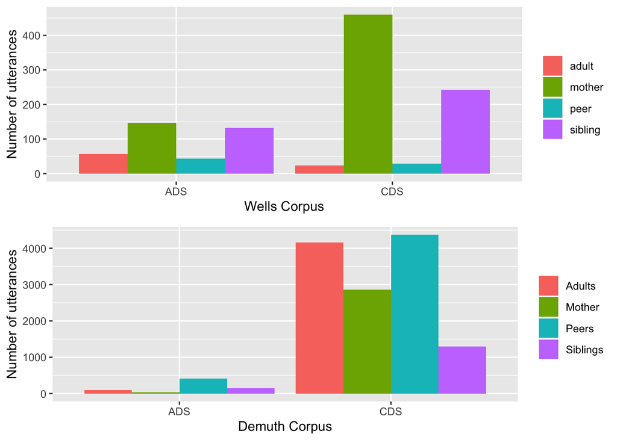

```r
#install libraries
library(ggplot2)
library(scales)
library(gridExtra)

#defining multiplot
multiplot <- function(..., plotlist=NULL, file, cols=1, layout=NULL) {
  library(grid)

  # Make a list from the ... arguments and plotlist
  plots <- c(list(...), plotlist)

  numPlots = length(plots)

  # If layout is NULL, then use 'cols' to determine layout
  if (is.null(layout)) {
    # Make the panel
    # ncol: Number of columns of plots
    # nrow: Number of rows needed, calculated from # of cols
    layout <- matrix(seq(1, cols * ceiling(numPlots/cols)),
                    ncol = cols, nrow = ceiling(numPlots/cols))
  }

 if (numPlots==1) {
    print(plots[[1]])

  } else {
    # Set up the page
    grid.newpage()
    pushViewport(viewport(layout = grid.layout(nrow(layout), ncol(layout))))

    # Make each plot, in the correct location
    for (i in 1:numPlots) {
      # Get the i,j matrix positions of the regions that contain this subplot
      matchidx <- as.data.frame(which(layout == i, arr.ind = TRUE))

      print(plots[[i]], vp = viewport(layout.pos.row = matchidx$row,
                                      layout.pos.col = matchidx$col))
    }
  }
}

#not normalized / all corpus
wells_full <- ggplot(sum_wells, aes( y=nb_utt, x=keychild, fill=speaker))+
  geom_bar(stat="identity", position="dodge")
demuth_full <- ggplot(sum_demuth, aes( y=nb_utt, x=keychild, fill=speaker))+
  geom_bar(stat="identity", position="dodge")

#not normalized / all corpus
wells_annot<- ggplot(sum_wells_annotated, aes( y=nb_utt, x=keychild, fill=speaker))+
  geom_bar(stat="identity", position="dodge")
demuth_annot<- ggplot(sum_demuth_annotated, aes( y=nb_utt, x=keychild, fill=speaker))+
  geom_bar(stat="identity", position="dodge")



wells_addresse<- ggplot(sum_wells_addressee, aes( y=nb_utt, x=keychild, fill=addresse))+
  geom_bar(stat="identity", position="dodge")
demuth_addresse<- ggplot(sum_demuth_addressee, aes( y=nb_utt, x=keychild, fill=addresse))+
  geom_bar(stat="identity", position="dodge")


#remove catherine for plot
demuth_fig<-subset(demuth_fig, !(demuth_fig$speaker=="investigator"))




#this is the code for the figuresss

wells_ADSCDS<- ggplot(wells_fig, aes( y=as.numeric(nb_utt), x=input, fill=speaker))+
  geom_bar(stat="identity", position="dodge") +  labs(x="Wells Corpus", y="Number of utterances") + guides(fill=guide_legend(title=NULL))
demuth_ADSCDS<- ggplot(demuth_fig, aes( y=as.numeric(nb_utt), x=input, fill=speaker))+
  geom_bar(stat="identity", position="dodge") +  labs(x="Demuth Corpus", y="Number of utterances") + scale_fill_discrete(labels= c("Adults", "Mother", "Peers", "Siblings")) + guides(fill=guide_legend(title=NULL))




#panel
 # multiplot (wells_full, demuth_full, cols=1)
 # multiplot (wells_annot, demuth_annot, cols=1)
 #

 #fill <- multiplot (wells_CDS, demuth_CDS, cols=1)
 dodge <- multiplot (wells_ADSCDS, demuth_ADSCDS, cols=1)
```